# CaseStudy_1_cyclistic_company

sruthy kannath

2022-07-27

## Introduction

You are a junior data analyst working in the marketing analyst team at Cyclistic, a bike-share company in Chicago. The director of marketing believes the company’s future success depends on maximizing the number of annual memberships. Therefore, your team wants to understand how casual riders and annual members use Cyclistic bikes differently. From these insights, your team will design a new marketing strategy to convert casual riders into annual members. But first, Cyclistic executives must approve your recommendations, so they must be backed up with compelling data insights and professional data visualizations.

## Prepare

```r
library(geosphere)
library(tidyverse)
```

```r
library(ggplot2)
library(lubridate)
library(dplyr)
library(readr)
library(janitor)
library(data.table)
library(tidyr)
```

### Reading data sets from .csv file and merge in to single data set

```r
june2021 <- read.csv("Bike_Ride_files/spreadsheets/202106-divvy-tripdata.csv")
july2021 <- read.csv("Bike_Ride_files/spreadsheets/202107-divvy-tripdata.csv")
aug2021 <- read.csv("Bike_Ride_files/spreadsheets/202108-divvy-tripdata.csv")
sep2021 <- read.csv("Bike_Ride_files/spreadsheets/202109-divvy-tripdata.csv")
oct2021 <- read.csv("Bike_Ride_files/spreadsheets/202110-divvy-tripdata.csv")
nov2021 <- read.csv("Bike_Ride_files/spreadsheets/202111-divvy-tripdata.csv")
dec2021 <- read.csv("Bike_Ride_files/spreadsheets/202112-divvy-tripdata.csv")
jan2022 <- read.csv("Bike_Ride_files/spreadsheets/202201-divvy-tripdata.csv")
feb2022 <- read.csv("Bike_Ride_files/spreadsheets/202202-divvy-tripdata.csv")
mar2022 <- read.csv("Bike_Ride_files/spreadsheets/202203-divvy-tripdata.csv")
apr2022 <- read.csv("Bike_Ride_files/spreadsheets/202204-divvy-tripdata.csv")
may2022 <- read.csv("Bike_Ride_files/spreadsheets/202205-divvy-tripdata.csv")
june2022 <- read.csv("Bike_Ride_files/spreadsheets/202206-divvy-tripdata.csv")
```

### after importing individual data sets from june 2021 to june 2022 in to single data set

```r
tripdata<-bind_rows(june2021,july2021,aug2021,sep2021,oct2021,nov2021,dec2021,jan2022,feb2022,mar2022,apr2022,may2022,june2022)
```

## Process

The process phase mainly includes cleaning the data from errors to transform the data in to effective one for analysis ### checking merged data frame

```r
#column names of merged data

colnames(tripdata)
```

```
##  [1] "ride_id"            "rideable_type"      "started_at"
##  [4] "ended_at"           "start_station_name" "start_station_id"
##  [7] "end_station_name"   "end_station_id"     "start_lat"
## [10] "start_lng"          "end_lat"            "end_lng"
## [13] "member_casual"
```

```r
#First 6 rows of trip data

head(tripdata)
```

```
##            ride_id rideable_type          started_at            ended_at
## 1 99FEC93BA843FB20 electric_bike 2021-06-13 14:31:28 2021-06-13 14:34:11
## 2 06048DCFC8520CAF electric_bike 2021-06-04 11:18:02 2021-06-04 11:24:19
## 3 9598066F68045DF2 electric_bike 2021-06-04 09:49:35 2021-06-04 09:55:34
## 4 B03C0FE48C412214 electric_bike 2021-06-03 19:56:05 2021-06-03 20:21:55
## 5 B9EEA89F8FEE73B7 electric_bike 2021-06-04 14:05:51 2021-06-04 14:09:59
## 6 62B943CEAAA420BA electric_bike 2021-06-03 19:32:01 2021-06-03 19:38:46
##   start_station_name start_station_id end_station_name end_station_id start_lat
## 1                                                                         41.80
## 2                                                                         41.79
## 3                                                                         41.80
## 4                                                                         41.78
## 5                                                                         41.80
## 6                                                                         41.78
##   start_lng end_lat end_lng member_casual
## 1    -87.59   41.80  -87.60        member
## 2    -87.59   41.80  -87.60        member
## 3    -87.60   41.79  -87.59        member
## 4    -87.58   41.80  -87.60        member
## 5    -87.59   41.79  -87.59        member
## 6    -87.58   41.78  -87.58        member
```

```r
#list of columns and data typs
str(tripdata)
```

```
## 'data.frame':    6629980 obs. of  13 variables:
##  $ ride_id           : chr  "99FEC93BA843FB20" "06048DCFC8520CAF" "9598066F68045DF2" "B03C0FE48C412214" ...
##  $ rideable_type     : chr  "electric_bike" "electric_bike" "electric_bike" "electric_bike" ...
##  $ started_at        : chr  "2021-06-13 14:31:28" "2021-06-04 11:18:02" "2021-06-04 09:49:35" "2021-06-03 19:56:05" ...
##  $ ended_at          : chr  "2021-06-13 14:34:11" "2021-06-04 11:24:19" "2021-06-04 09:55:34" "2021-06-03 20:21:55" ...
##  $ start_station_name: chr  "" "" "" "" ...
##  $ start_station_id  : chr  "" "" "" "" ...
##  $ end_station_name  : chr  "" "" "" "" ...
##  $ end_station_id    : chr  "" "" "" "" ...
##  $ start_lat         : num  41.8 41.8 41.8 41.8 41.8 ...
##  $ start_lng         : num  -87.6 -87.6 -87.6 -87.6 -87.6 ...
##  $ end_lat           : num  41.8 41.8 41.8 41.8 41.8 ...
##  $ end_lng           : num  -87.6 -87.6 -87.6 -87.6 -87.6 ...
##  $ member_casual     : chr  "member" "member" "member" "member" ...
```

```r
#Adding columns for date, month, year, day of the week into the data frame.
tripdata$date <- as.Date(tripdata$started_at)
tripdata$month <- format(as.Date(tripdata$date), "%m")
tripdata$day <- format(as.Date(tripdata$date), "%d")
tripdata$year <- format(as.Date(tripdata$date), "%Y")
tripdata$day_of_week <- format(as.Date(tripdata$date), "%A")
colnames(tripdata) #to get the names of all the columns
```

```
##  [1] "ride_id"            "rideable_type"      "started_at"
##  [4] "ended_at"           "start_station_name" "start_station_id"
##  [7] "end_station_name"   "end_station_id"     "start_lat"
## [10] "start_lng"          "end_lat"            "end_lng"
## [13] "member_casual"      "date"               "month"
## [16] "day"                "year"               "day_of_week"
```

```r
#Add a ride_length calculation to tripdata
tripdata$ride_length <- difftime(tripdata$ended_at, tripdata$started_at)
str(tripdata) #to inspect the structure of the columns
```

```
## 'data.frame':    6629980 obs. of  19 variables:
##  $ ride_id           : chr  "99FEC93BA843FB20" "06048DCFC8520CAF" "9598066F68045DF2" "B03C0FE48C412214" ...
##  $ rideable_type     : chr  "electric_bike" "electric_bike" "electric_bike" "electric_bike" ...
##  $ started_at        : chr  "2021-06-13 14:31:28" "2021-06-04 11:18:02" "2021-06-04 09:49:35" "2021-06-03 19:56:05" ...
##  $ ended_at          : chr  "2021-06-13 14:34:11" "2021-06-04 11:24:19" "2021-06-04 09:55:34" "2021-06-03 20:21:55" ...
##  $ start_station_name: chr  "" "" "" "" ...
##  $ start_station_id  : chr  "" "" "" "" ...
##  $ end_station_name  : chr  "" "" "" "" ...
##  $ end_station_id    : chr  "" "" "" "" ...
##  $ start_lat         : num  41.8 41.8 41.8 41.8 41.8 ...
##  $ start_lng         : num  -87.6 -87.6 -87.6 -87.6 -87.6 ...
##  $ end_lat           : num  41.8 41.8 41.8 41.8 41.8 ...
##  $ end_lng           : num  -87.6 -87.6 -87.6 -87.6 -87.6 ...
##  $ member_casual     : chr  "member" "member" "member" "member" ...
##  $ date              : Date, format: "2021-06-13" "2021-06-04" ...
##  $ month             : chr  "06" "06" "06" "06" ...
##  $ day               : chr  "13" "04" "04" "03" ...
##  $ year              : chr  "2021" "2021" "2021" "2021" ...
##  $ day_of_week       : chr  "Sunday" "Friday" "Friday" "Thursday" ...
##  $ ride_length       : 'difftime' num  163 377 359 1550 ...
##   ..- attr(*, "units")= chr "secs"
```

```r
#converting ride_length to numeric value
tripdata$ride_length<-as.numeric(as.character(tripdata$ride_length))
is.numeric(tripdata$ride_length)
```

```
## [1] TRUE
```

```r
#ride_distance calculation

tripdata$ride_distance <- distGeo(matrix(c(tripdata$start_lng, tripdata$start_lat), ncol=2), matrix (c(tripdata$end_lng, tripdata$end_lat), ncol=2))
#distance in km
str(tripdata)
```

```
## 'data.frame':    6629980 obs. of  20 variables:
##  $ ride_id           : chr  "99FEC93BA843FB20" "06048DCFC8520CAF" "9598066F68045DF2" "B03C0FE48C412214" ...
##  $ rideable_type     : chr  "electric_bike" "electric_bike" "electric_bike" "electric_bike" ...
##  $ started_at        : chr  "2021-06-13 14:31:28" "2021-06-04 11:18:02" "2021-06-04 09:49:35" "2021-06-03 19:56:05" ...
##  $ ended_at          : chr  "2021-06-13 14:34:11" "2021-06-04 11:24:19" "2021-06-04 09:55:34" "2021-06-03 20:21:55" ...
##  $ start_station_name: chr  "" "" "" "" ...
##  $ start_station_id  : chr  "" "" "" "" ...
##  $ end_station_name  : chr  "" "" "" "" ...
##  $ end_station_id    : chr  "" "" "" "" ...
##  $ start_lat         : num  41.8 41.8 41.8 41.8 41.8 ...
##  $ start_lng         : num  -87.6 -87.6 -87.6 -87.6 -87.6 ...
##  $ end_lat           : num  41.8 41.8 41.8 41.8 41.8 ...
##  $ end_lng           : num  -87.6 -87.6 -87.6 -87.6 -87.6 ...
##  $ member_casual     : chr  "member" "member" "member" "member" ...
##  $ date              : Date, format: "2021-06-13" "2021-06-04" ...
##  $ month             : chr  "06" "06" "06" "06" ...
##  $ day               : chr  "13" "04" "04" "03" ...
##  $ year              : chr  "2021" "2021" "2021" "2021" ...
##  $ day_of_week       : chr  "Sunday" "Friday" "Friday" "Thursday" ...
##  $ ride_length       : num  163 377 359 1550 248 405 371 378 526 551 ...
##  $ ride_distance     : num  831 1387 1387 2775 1111 ...
```

```r
#Remove bad data by checking 0 or -ve ride_length
trip_data_clean <- tripdata[!(tripdata$ride_length <= 0),]
glimpse(trip_data_clean)
```

```
## Rows: 6,629,268
## Columns: 20
## $ ride_id            <chr> "99FEC93BA843FB20", "06048DCFC8520CAF", "9598066F68…
## $ rideable_type      <chr> "electric_bike", "electric_bike", "electric_bike", …
## $ started_at         <chr> "2021-06-13 14:31:28", "2021-06-04 11:18:02", "2021…
## $ ended_at           <chr> "2021-06-13 14:34:11", "2021-06-04 11:24:19", "2021…
## $ start_station_name <chr> "", "", "", "", "", "", "", "", "", "", "", "", "",…
## $ start_station_id   <chr> "", "", "", "", "", "", "", "", "", "", "", "", "",…
## $ end_station_name   <chr> "", "", "", "", "", "", "", "", "", "Michigan Ave &…
## $ end_station_id     <chr> "", "", "", "", "", "", "", "", "", "13042", "", ""…
## $ start_lat          <dbl> 41.80, 41.79, 41.80, 41.78, 41.80, 41.78, 41.79, 41…
## $ start_lng          <dbl> -87.59, -87.59, -87.60, -87.58, -87.59, -87.58, -87…
## $ end_lat            <dbl> 41.80000, 41.80000, 41.79000, 41.80000, 41.79000, 4…
## $ end_lng            <dbl> -87.6000, -87.6000, -87.5900, -87.6000, -87.5900, -…
## $ member_casual      <chr> "member", "member", "member", "member", "member", "…
## $ date               <date> 2021-06-13, 2021-06-04, 2021-06-04, 2021-06-03, 20…
## $ month              <chr> "06", "06", "06", "06", "06", "06", "06", "06", "06…
## $ day                <chr> "13", "04", "04", "03", "04", "03", "10", "10", "10…
## $ year               <chr> "2021", "2021", "2021", "2021", "2021", "2021", "20…
## $ day_of_week        <chr> "Sunday", "Friday", "Friday", "Thursday", "Friday",…
## $ ride_length        <dbl> 163, 377, 359, 1550, 248, 405, 371, 378, 526, 551, …
## $ ride_distance      <dbl> 831.0969, 1387.2521, 1387.2521, 2774.5801, 1110.693…
```

## ANALYSE

All the required information are now in one place and ready for exploration. ### Key tasks Aggregate your data so it’s useful and accessible. Organize and format your data. Perform calculations. Identify trends and relationships. ### Deliverable A summary of the analysis.

```r
str(trip_data_clean)
```

```
## 'data.frame':    6629268 obs. of  20 variables:
##  $ ride_id           : chr  "99FEC93BA843FB20" "06048DCFC8520CAF" "9598066F68045DF2" "B03C0FE48C412214" ...
##  $ rideable_type     : chr  "electric_bike" "electric_bike" "electric_bike" "electric_bike" ...
##  $ started_at        : chr  "2021-06-13 14:31:28" "2021-06-04 11:18:02" "2021-06-04 09:49:35" "2021-06-03 19:56:05" ...
##  $ ended_at          : chr  "2021-06-13 14:34:11" "2021-06-04 11:24:19" "2021-06-04 09:55:34" "2021-06-03 20:21:55" ...
##  $ start_station_name: chr  "" "" "" "" ...
##  $ start_station_id  : chr  "" "" "" "" ...
##  $ end_station_name  : chr  "" "" "" "" ...
##  $ end_station_id    : chr  "" "" "" "" ...
##  $ start_lat         : num  41.8 41.8 41.8 41.8 41.8 ...
##  $ start_lng         : num  -87.6 -87.6 -87.6 -87.6 -87.6 ...
##  $ end_lat           : num  41.8 41.8 41.8 41.8 41.8 ...
##  $ end_lng           : num  -87.6 -87.6 -87.6 -87.6 -87.6 ...
##  $ member_casual     : chr  "member" "member" "member" "member" ...
##  $ date              : Date, format: "2021-06-13" "2021-06-04" ...
##  $ month             : chr  "06" "06" "06" "06" ...
##  $ day               : chr  "13" "04" "04" "03" ...
##  $ year              : chr  "2021" "2021" "2021" "2021" ...
##  $ day_of_week       : chr  "Sunday" "Friday" "Friday" "Thursday" ...
##  $ ride_length       : num  163 377 359 1550 248 405 371 378 526 551 ...
##  $ ride_distance     : num  831 1387 1387 2775 1111 ...
```

```r
#summary of claean data
summary(trip_data_clean)
```

```
##    ride_id          rideable_type       started_at          ended_at
##  Length:6629268     Length:6629268     Length:6629268     Length:6629268
##  Class :character   Class :character   Class :character   Class :character
##  Mode  :character   Mode  :character   Mode  :character   Mode  :character
##
##
##
##
##  start_station_name start_station_id   end_station_name   end_station_id
##  Length:6629268     Length:6629268     Length:6629268     Length:6629268
##  Class :character   Class :character   Class :character   Class :character
##  Mode  :character   Mode  :character   Mode  :character   Mode  :character
##
##
##
##
##    start_lat       start_lng         end_lat         end_lng
##  Min.   :41.64   Min.   :-87.84   Min.   :41.39   Min.   :-88.97
##  1st Qu.:41.88   1st Qu.:-87.66   1st Qu.:41.88   1st Qu.:-87.66
##  Median :41.90   Median :-87.64   Median :41.90   Median :-87.64
##  Mean   :41.90   Mean   :-87.65   Mean   :41.90   Mean   :-87.65
##  3rd Qu.:41.93   3rd Qu.:-87.63   3rd Qu.:41.93   3rd Qu.:-87.63
##  Max.   :45.64   Max.   :-73.80   Max.   :42.17   Max.   :-87.49
##                                   NA's   :6091    NA's   :6091
##  member_casual           date               month               day
##  Length:6629268     Min.   :2021-06-01   Length:6629268     Length:6629268
##  Class :character   1st Qu.:2021-08-05   Class :character   Class :character
##  Mode  :character   Median :2021-10-09   Mode  :character   Mode  :character
##                     Mean   :2021-11-21
##                     3rd Qu.:2022-04-11
##                     Max.   :2022-06-30
##
##      year           day_of_week         ride_length      ride_distance
##  Length:6629268     Length:6629268     Min.   :      1   Min.   :      0
##  Class :character   Class :character   1st Qu.:    384   1st Qu.:    896
##  Mode  :character   Mode  :character   Median :    684   Median :   1622
##                                        Mean   :   1255   Mean   :   2178
##                                        3rd Qu.:   1239   3rd Qu.:   2862
##                                        Max.   :3356649   Max.   :1192246
##                                                          NA's   :6091
```

visualize the count of members and casuals by their ride

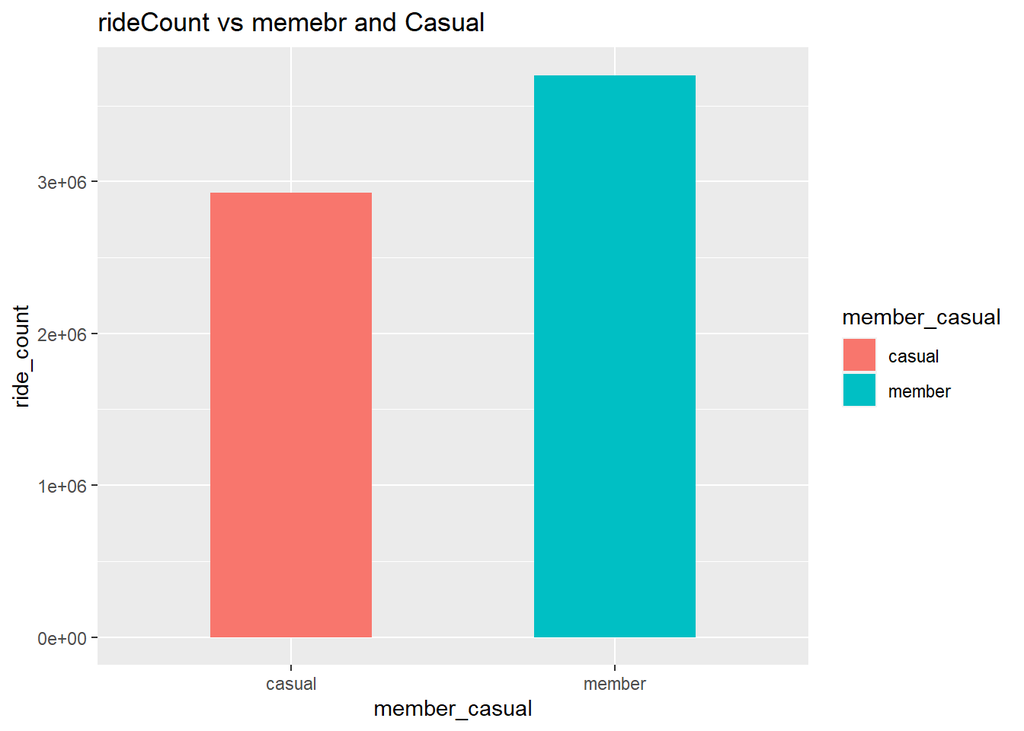

```r
trip_data_clean %>%
    group_by(member_casual) %>%
    summarise(ride_count = length(ride_id)) %>% ggplot(aes(x = member_casual, y = ride_count,fill = member_casual))  +
    geom_col(width=0.5, position = position_dodge(width=0.5))+
  labs(title ="rideCount vs memebr and Casual")
```

- From the above graph its clear that member make more ride count than casuals

### orderdata by weekdyas

```r
trip_data_clean$day_of_week <- ordered(trip_data_clean$day_of_week,
                                    levels=c("Sunday", "Monday", "Tuesday", "Wednesday", "Thursday", "Friday", "Saturday"))

trip_data_clean %>%
  group_by(member_casual, day_of_week) %>%  #groups by member_casual
  summarise(number_of_rides = n() #calculates the number of rides and average duration
  ,average_ride_length = mean(ride_length),.groups="drop") %>% # calculates the average duration
  arrange(member_casual, day_of_week) #sort
```

```
## # A tibble: 14 × 4
##    member_casual day_of_week number_of_rides average_ride_length
##    <chr>         <ord>                 <int>               <dbl>
##  1 casual        Sunday               535945               2127.
##  2 casual        Monday               339043               1838.
##  3 casual        Tuesday              325804               1612.
##  4 casual        Wednesday            334117               1621.
##  5 casual        Thursday             366556               1686.
##  6 casual        Friday               415836               1758.
##  7 casual        Saturday             611222               2002.
##  8 member        Sunday               443707                894.
##  9 member        Monday               512871                763.
## 10 member        Tuesday              579749                745.
## 11 member        Wednesday            581356                744.
## 12 member        Thursday             575273                756.
## 13 member        Friday               517085                774.
## 14 member        Saturday             490704                881.
```

## Visualize the ride data of mebers and casuals by weekdays vs number of rides

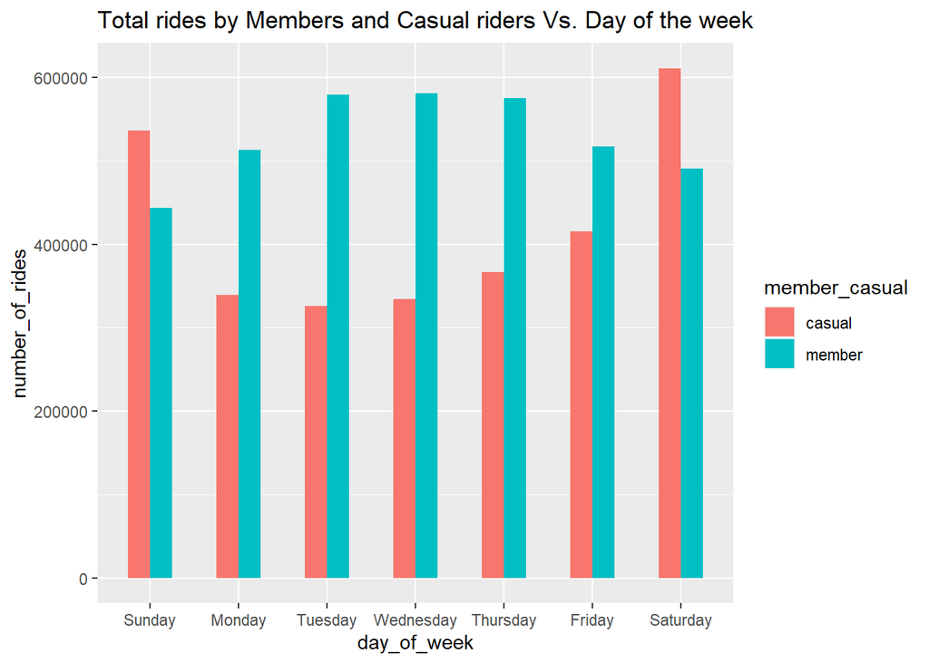

```r
trip_data_clean %>%
  group_by(member_casual, day_of_week) %>%
  summarise(number_of_rides = n(), .groups="drop") %>%
  arrange(member_casual, day_of_week)  %>%
  ggplot(aes(x = day_of_week, y = number_of_rides, fill = member_casual)) +
  labs(title ="Total rides by Members and Casual riders Vs. Day of the week") +
  geom_col(width=0.5, position = position_dodge(width=0.5)) +
  scale_y_continuous(labels = function(x) format(x, scientific = FALSE))
```

### Visualize avarge ride time vs of members and casuals by week dyas

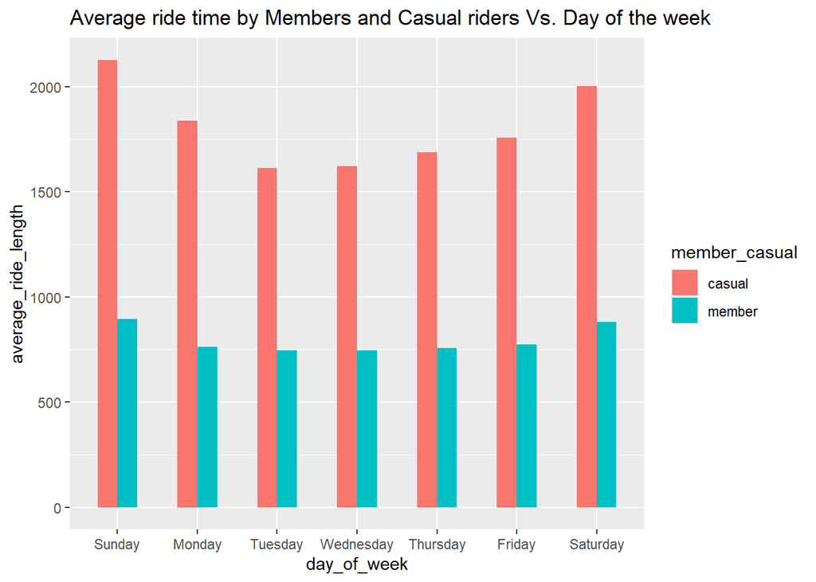

```r
trip_data_clean %>%
  group_by(member_casual, day_of_week) %>%
  summarise(average_ride_length = mean(ride_length), .groups="drop") %>%
  ggplot(aes(x = day_of_week, y = average_ride_length, fill = member_casual)) +
  geom_col(width=0.5, position = position_dodge(width=0.5)) +
  labs(title ="Average ride time by Members and Casual riders Vs. Day of the week")
```

-From the first chart above members took consistent trips throughout the week, but there is less rides in Sunday. For casual riders the most taken rides are in weekends, starting rise in Friday followed by Saturday and Sunday. -The average ride length for members are much much less than that of casual riders. Also it can be seen that weekend average ride length is much higher for casual riders along with total rides.

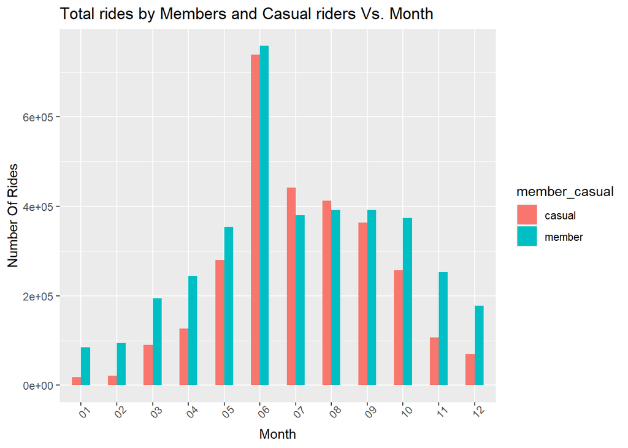

```r
trip_data_clean$month <- ordered(trip_data_clean$month)


trip_data_clean %>%
  group_by(member_casual, month) %>%
  summarise(number_of_rides = n(), average_ride_length = mean(ride_length), .groups="drop") %>%
  arrange(member_casual, month) %>% ggplot(aes(x=month,y=number_of_rides,fill=member_casual))+
    labs(title ="Total rides by Members and Casual riders Vs. Month", x = "Month", y= "Number Of Rides") +
  theme(axis.text.x = element_text(angle = 45)) +
  geom_col(width=0.5, position = position_dodge(width=0.5))
```

```r
trip_data_clean %>%
    group_by(rideable_type) %>%
    summarise(count = length(ride_id))
```

```
## # A tibble: 3 × 2
##   rideable_type   count
##   <chr>           <int>
## 1 classic_bike  3624117
## 2 docked_bike    305079
## 3 electric_bike 2700072
```

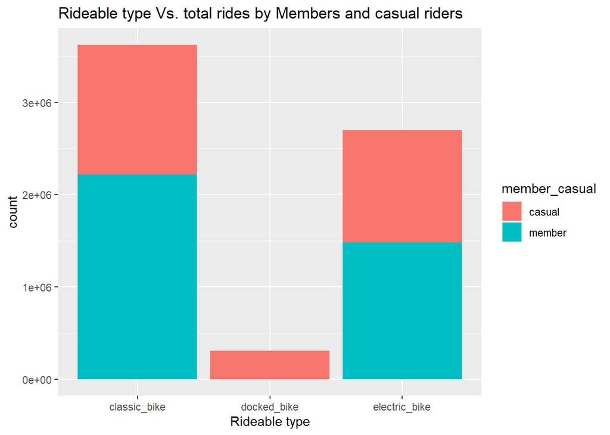

```r
ggplot(trip_data_clean, aes(x=rideable_type, fill=member_casual)) +
    labs(x="Rideable type", title="Rideable type Vs. total rides by Members and casual riders") +
    geom_bar()
```

-From the above viz we can see that members mostly use classic bikes, followed by electric bikes Docked bikes mostly used by casual riders. Electric bikes are more favored by members.

# Share

This phase done by presentation .Here I am using R markdown to make my presention doc .

# Act

Act phase will be done by the Cyclistic’s executive team, Director of Marketing (Lily Moreno), Marketing Analytics team on the basis of my analysis. (Data-driven decision making) ## Top 3 recommendatiosn * Provide weekend offers for casual riders if they are willing to paid member * Create market campaigns for attracting more casuals to members * Incerase the number electri bike as the demand for electric bike are high in trend .